# ML4econ Prerequisite

Dor Goldenberg

26 February, 2020

Hi everyone and welcome to the ml4econ course (stands for Machine Learning for economists)!

### About the Course

In this course we will go over ML (stands for “machine learning”) algorithms that can be used in economics. The first part of the course will focus on some classic models in ML (you are probably familiar with some of them). The second part of the course will focus on causality in ML. Since economics is mostly focused on causality the absence of it from classic ML framework avoids the vast adoption of it by economists. Therefore we will go over some classic ML algorithms and then we will look at some adaptions of them to causal inference framework.

#### Exercises

1. ML tools have shown some incredible successes over the last decade in multiple areas. The ML field tackled both novel problems like: Image Processing, Voice Recognition, User Recommendation, Natural Language Processing - and more classic problems like classification and regression problems. Why can’t we simply apply those methods to economic issues - policy problems, for examples?
2. Linear Regression model doesn’t in itself implies causality. What else needed in order to use the regression coefficients as causal? Why is it not quite easy to get in ML?
3. Due to convenience economists mostly use linear models. Since we are going to use other structural forms let’s discuss those assumptions explicitly. This will give us better understanding of the difference between models.
- What is the intuitive meaning of the linearity assumption?
- What is the intuitive meaning of the separability assumption?
- What are the encapsulated meanings in $X \sim \mathcal{N}(\mu,\,\sigma^{2})\,$?

### R

Throughout the course we will be using the `R` programming language both in class and in problem sets. If you are not familiar with it or if you don’t have enough experience in programming with `R` than you should probably start in some basic `R` courses. You will find many of them online. You can find some material in the following links:

1. You can find some introduction[in here](https://www.guru99.com/r-programming-introduction-basics.html).
2. This is a somewhat [Extensive book](http://www.john-ros.com/Rcourse/) on `R` written by Jonathan Rosenblatt from Ben-Gurion University. It covers many topics in `R`, from basics like what is `R` to very advanced topics like parallel computing.
3. Make sure that you take the datacamp course. You all got access.

#### Exercises

1. If you don’t have it yet make sure you install `R`. You can find it [here](https://cran.r-project.org/bin/windows/base/).

### RStudio

RStudio is an “integrated development environment” (IDE) for `R`. IDE “is a software application that provides comprehensive facilities to computer programmers for software development. An IDE normally consists of at least a source code editor, build automation tools and a debugger.” [(Wikipedia)](https://en.wikipedia.org/wiki/Integrated_development_environment).

Most of `R` practitioners use RStudio so you can use the same materials to learn the abilities of RStudio. You can find some intro in [here](https://data-flair.training/blogs/rstudio-tutorial/).

#### Exercises

1. If you don’t have it yet make sure you install RStudio. You can find it [here](https://rstudio.com/products/rstudio/download/#download).

### The “Tidyverse”

The Tidyverse is a bundle of packages (and if you can’t recall what a package is you better go back to the former sections) that makes the use of `R` much more easy practically and conceptually. It contains multiple packages that serve multiple ends:

- `dplyr` for data manipulation
- `tidyr` for tidying data
- `ggplot2` for visualizing data
- `readr` for reading different sources of data
- `stringr` for dealing with regular expressions
- `lubridate` for dealing with dates

and much more. Since the `tidyverse` covers a lot of topics we can’t cover it here. The main package to focus on is the the `dplyr` package. The `dplyr` package provides a powerful SQL-like toolkit for data manipulation. What are the main functions you should know?

- `filter`: filters the data by row-wise conditions
- `select` allows you to select columns from dataframes
- `group_by` perform operation on defined groups
- `mutate` creates new columns
- `summarise` reduces multiple values down to a single summary

In addition, you should get familiar with `magrittr`’s (another package from the tidyverse) “pipe” operator `%>%` - this operator “plucks” the variable before the pipe in the first argument of the following function.

If you are not familiar with the tidyverse start to traverse [here](https://r4ds.had.co.nz/transform.html) and [here](https://www.tidyverse.org/packages/).

Anothe useful `tidyverse` package is `ggplot2`, THE go-to package to visualize your data in R. The basic philosophy is layers stacking. You can define almost every element in the way you visualize your data. Check [here](https://ggplot2.tidyverse.org/) and [here](http://r-statistics.co/Complete-Ggplot2-Tutorial-Part1-With-R-Code.html) for some more information.

[Kieran Healy’s Data Visualization](https://socviz.co/) e-book is also highly recommended.

#### Exercises

1. Install and load the `tidyverse` and `kableExtra` packages:

```r
# install.packages(c("tidyverse", "kableExtra"))

library(tidyverse)  # for wrangling and visualizing data
library(kableExtra) # for fancy tables
```

2. Load the `iris` data by using `data(iris)`. Now do the following set of actions using a `tidy` vocabulary: select the sepal columns and the species’ names. Next, calculate the mean of the sepal length per species. Name the column “Average_Sepal_Length”. Make sure you are using the pipe operator throughout.

```r
data(iris)

iris %>%
  select(c(starts_with("Sepal"), Species)) %>%
  group_by(Species) %>%
  summarise(Average_Sepal_Length = mean(Sepal.Length)) %>%
  kable() %>%
  kable_styling()
```

| Species | Average_Sepal_Length |
| --- | --- |
| setosa | 5.006 |
| versicolor | 5.936 |
| virginica | 6.588 |

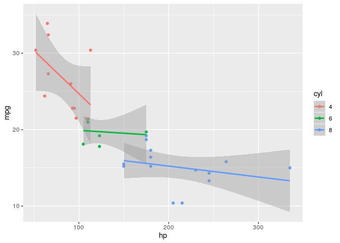

```r
data("mtcars")

mtcars %>%
  mutate(cyl = as_factor(cyl)) %>%
  ggplot(aes(x = hp, y = mpg, color = cyl)) +
  geom_point()+
  geom_smooth(method="lm", size=1)
```

### Git & GitHub

Git is a tool for version control. It allows documentation and reproducibility of your code. Unfortunately, `R` users do not give enough attention to version control, probably due to the non-production nature of their work.

GitHub is a GUI (Graphical User Interface) for Git. It allows to run all the commands of Git in a graphical way. It also has repositories that help to document and reproduce the work. We will now go over some steps that will allow us to learn about the uses of Git & GitHub.

We will now go over several steps. We will use Git from the command line (in Windows). It is highly recommended that you will read the following [manual](https://git-scm.com/book/en/v2/Getting-Started-About-Version-Control).

#### Steps

1. Install Git: First, follow the instructions [here](https://git-scm.com/book/en/v2/Getting-Started-Installing-Git) to install Git.
2. Install GitHub: Install GitHub from [here](https://github.com/).
3. Configure: Introduce yourself to git. First, install the package `usethis`. Then, load it and use the `use_git_config` function to introduce yourseld to git:

```r
# install.packages("usethis")

library(usethis)

use_git_config(
  scope = "project",
  user.name = "Jane",
  user.email = "jane@example.org"
)
```

4. Initialize Repository: You can initialize repository by cloning existing one or by making a directory to a repo. Use the `cd` function to define a directory as a destiny: `cd C:/Users/dorgo/myproject` (adapt it to your path). Then use `git init` to initialize a repo. Afterwards you can `add` files and `commit` (we will go over it). If you want to clone a repo you just need to use the `git clone <url>`. For example, `git clone https://github.com/libgit2/libgit2`.
5. Stage: Staging tells Git to track a file, before it committed. After staging the file is waiting to enter the primary version (by `commit`). In order to stage use the `git add` function: `git add awa` (awa is a file in my the git directory). You can check the status of the files by using the `git status` function. Check also the `git diff` function.
6. Commit: Commit insert your version changes into action. Every time you perform a commit, you’re recording a snapshot of your project that you can revert to or compare to later. Use `git commit` to commit all staged changes. Add description for clarity by adding -m: `git commit -m “your note (bug fix 16, for example)”.
7. Log: The `git log` function shows you the history of your repo.
8. Remote: Remotes are distant repos. `git remote` shows you to what repos you are connected. The `git add remote <url>` function creates a remote. `git fetch <remote>` updates your repo with all the changes.
9. Branch: Branches allows you to deviate from the main route and make changes in your code without it affects other branches. Use the `git branch <name>` function to create a branch. In order to switch between branches use `git checkout <branch>`.
10. Merge: When you are satisfied with your branch you can merge it with other branches. Use the `git merge <branch>` function to merge. Sometimes you will have a conflict - a changes that were done to the same code in different branches. Git will tell you that you have a conflict. You will have to fix your conflicts before merging.

#### Exercises

1. There are much more options in Git than was covered here. Make sure to read some more and practice!
2. As mentioned, `GitHub` is a GUI for Git. Try to do the same steps that we did here in GitHub.

Good luck!